# TP Statistiques

Gabriel CANAPLE, BOYER THOMAS, LECLUSE Martin, FAYALA Mohamed

19 Janvier 2024

(décrire la régression, l’état des résidus, le test de normalité, est-elle centrée, variance est constante ? indépendance ?) test de shapiro, student, chi2 régression linéaire = chap 6 du cours y = ax + b + epsilon y = variable expliquée a, b = inconnues x = variable explicative epsilon = résidus test de pertinence : a=0? test de biais : b=0?

on peut aussi avoir plusieurs variables explicatives : y = a1*x1 + a2*x2 + … + an*xn + epsilon

PENSER A définir le risque alpha pour chacun des tests (si on sait pas quoi prendre prendre 5%)

# Introduction

L’objectif du TP est de comparer les performances d’algorithmes de calcul de circuit hamiltonien dans un graphe, selon les critères de longueur du chemin, et de temps d’exécution.

Nos conclusions se basent tout au long du TP sur les méthodes statistiques aabordées en cours : test d’hypothèse, tests multiples, régression linéaire.

Dans une première partie, nous montrerons une visualisation du problème résolu par les algorithmes, puis nous comparerons ces derniers sur le critère de la longueur du chemin hamiltonien trouvé, et ensuite sur le temps d’exécution. Enfin, nous essayerons de proposer une régression linéaire de la complexité de l’algorithme Branch & Bound.

# 1. Visualisation de chemins

Voici les données présentes dans le fichier “DonneesGPSvilles.csv” :

```r
set.seed(35)
villes <- read.csv('DonneesGPSvilles.csv',header=TRUE,dec='.',sep=';',quote="\"")
str(villes)
```

```
## 'data.frame':    22 obs. of  5 variables:
##  $ EU_circo : chr  "Sud-Est" "Sud-Est" "Nord-Ouest" "Est" ...
##  $ region   : chr  "Rhône-Alpes" "Corse" "Picardie" "Franche-Comté" ...
##  $ ville    : chr  "Lyon" "Ajaccio" "Amiens" "Besançon" ...
##  $ latitude : num  45.7 41.9 49.9 47.2 44.8 ...
##  $ longitude: num  4.847 8.733 2.3 6.033 -0.567 ...
```

Et voici comment nous visualisaons les résultats données par les algorithmes (ici, avec l’exemple de l’algorithme “nearest”, comaré au chemin optimal fourni) :

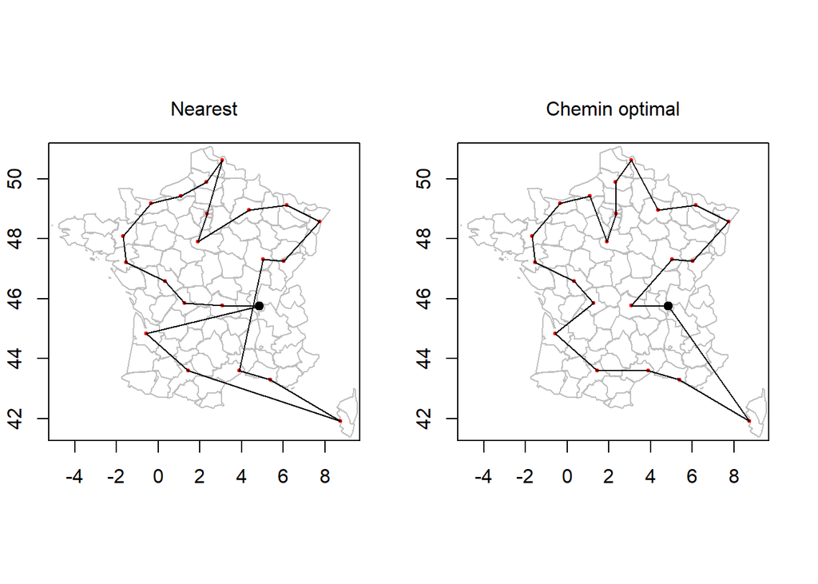

```r
set.seed(35)
coord <- cbind(villes$longitude,villes$latitude)
dist <- distanceGPS(coord)
voisins <- TSPnearest(dist)

pathOpt <- c(1,8,9,4,21,13,7,10,3,17,16,20,6,19,15,18,11,5,22,14,12,2)

par(mfrow=c(1,2),mar=c(1,1,2,1))
plotTrace(coord[voisins$chemin,], title='Nearest')
plotTrace(coord[pathOpt,], title='Chemin optimal')
```

Le total de la longueurs des trajets (à vol d’oiseau) valent respectivement, pour la méthode des plus proches voisins :

```
## [1] 4303.568
```

et pour la méthode optimale :

```
## [1] 3793.06
```

On remarque que le résultat de l’algorithme est peu performant, avec de incohérences que l’on peut facilement voir sur la carte, et qui sont confirmées par le total de la longueur des chemins.

Cela illustre l’intérêt de notre démarche : il faut pouvoir objectifier la performance des algorithmes pour les comparer entre eux, et sélectionner le meilleur (selon certains critères).

C’est l’objet des parties suivantes.

# 2. Comparaison d’algorithmes

On fixe le nombre de somets du graphe à 10. Les coordonnées cartésiennes sont des lois uniformes sur [0,1] :

```r
set.seed(35)
n <- 10 #nombre de noeuds

#exemple de lancement unitaire
sommets <- data.frame(x = runif(n), y = runif(n))
couts <- distance(sommets)
TSPsolve(dist,'nearest') #LE RESULTAT ICI ME PARAIT BIZARRE (4000 alors que ya que des coordonnées entre 0 et 1, on est surs qu'on l'appelle avec le bon jeu de données ?)
```

```
## [1] 4303.568
```

On lance 50 simulations par algorithme, ce qui donne le résultat suivant (premières lignes uniquement) :

```
## [1] 2.633229 2.825005 2.770953 2.190799 2.912380
```

### 2.1. Longueur des chemins

On s’intéresse ici à la longueur des chemins retournée par chacun des méthodes. Notre but est de détermnier quel(s) algorithme(s) est le plus performant selon ce critère, c’est-à-dire renvoie une longueur la plus faible possible. Pour répondre à cette question, on visualisera d’abord les résultats, avant de mener des études plus approfondies, d’abord sur les algorithmes “nearest” et “branch & bound”, puis entre tous les algortihmes 2 à 2.

### Observation des résultats

Voici d’abord une visualisation des résultats sous forme de boxplot :

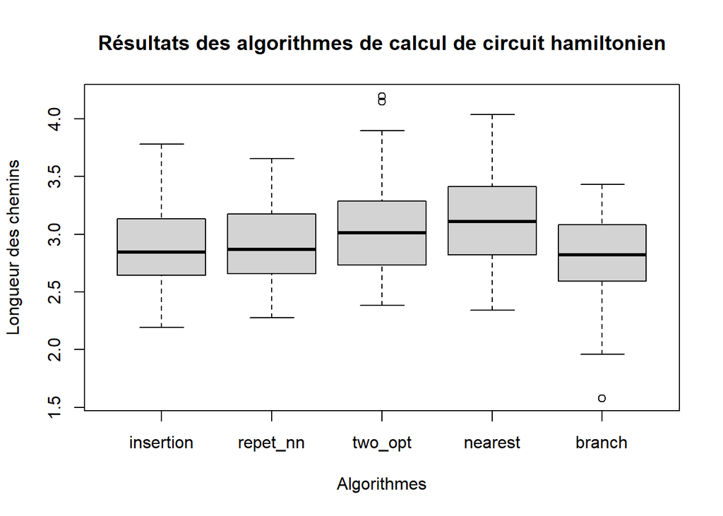

```r
set.seed(35)
res2 <- as.vector(res)
meth_names <- c('insertion','repetitive_nn','two_opt','nearest','branch')
methods2 <- rep(meth_names,each=nsimu)

boxplot(res,
        main="Résultats des algorithmes de calcul de circuit hamiltonien",
        xlab="Algorithmes",
        ylab="Longueur des chemins")
```

### Test de normalité

```r
shapiro.test(res[,1])
```

```
##
##  Shapiro-Wilk normality test
##
## data:  res[, 1]
## W = 0.97675, p-value = 0.4246
```

```r
shapiro.test(res[,2])
```

```
##
##  Shapiro-Wilk normality test
##
## data:  res[, 2]
## W = 0.97601, p-value = 0.3983
```

```r
shapiro.test(res[,3])
```

```
##
##  Shapiro-Wilk normality test
##
## data:  res[, 3]
## W = 0.95152, p-value = 0.03939
```

```r
shapiro.test(res[,4])
```

```
##
##  Shapiro-Wilk normality test
##
## data:  res[, 4]
## W = 0.96797, p-value = 0.1911
```

```r
shapiro.test(res[,5])
```

```
##
##  Shapiro-Wilk normality test
##
## data:  res[, 5]
## W = 0.95604, p-value = 0.06067
```

### Comparaison de “nearest” et de “branch & bound”

Notre premier objectif est de comparer les performances de “nearest” et de “branch & bound”. En effet, ce sont les algorithmes qui ont a priori le plus de chances d’être significativement différents (cf boxplot).

On cherche à savoir si “nearest” est significativement moins performant que “branch & bound”, donc on pose les hypothèse suivantes $H(0) : m_n - m_bb <= 0$ et $H(1) : m_n-m_bb > 0$. De cette manière, on contrôle le risque de conclure que “nearest” est meilleur que “branch & bound” alors que ce n’est pas le cas. A noter que, ici, l’algorithme le plus performant trouve une longueur plus faible.

Pour ce test, on prend un seuil de risque de 5%.

```r
nearest_branch <- res[,4] - res[,5]
t.test(res[,4], res[,5], alternative = "greater")
```

```
##
##  Welch Two Sample t-test
##
## data:  res[, 4] and res[, 5]
## t = 4.0462, df = 97.621, p-value = 5.211e-05
## alternative hypothesis: true difference in means is greater than 0
## 95 percent confidence interval:
##  0.1814195       Inf
## sample estimates:
## mean of x mean of y
##  3.119036  2.811328
```

### Tests deux à deux

L’objectif de cette analyse est de déterminer si l’on peut regrouper les différents algorithmes par performance sur le critère de longueur des chemins trouvés. Cela permettra de présenter les résultats sous une forme plus intelligible, et éventuellement de faire plus tard des choix entre les algorithmes pus facilement (en prenant d’autres critères comme le temps d’exécution par exemple).

```r
result <- pairwise.t.test(res2,methods2, p.adjust.method = "bonferroni")
result
```

```
##
##  Pairwise comparisons using t tests with pooled SD
##
## data:  res2 and methods2
##
##               branch  insertion nearest repetitive_nn
## insertion     1.00000 -         -       -
## nearest       0.00052 0.03281   -       -
## repetitive_nn 1.00000 1.00000   0.07124 -
## two_opt       0.00441 0.16646   1.00000 0.32098
##
## P value adjustment method: bonferroni
```

## 2.2. Temps de calcul

Après avoir étudié les performances des algorithmes selon la longueur des chemins trouvés, nous étudions les performances en termes de temps de calcul.

On exécute les algorithmes 20 fois, les coordonnées des points sont comme précédemment générés par une lois uniforme sur [0,1].

On utilise pour cela le package “microbenchmark” :

```r
set.seed(35)

microbenchmark::microbenchmark(TSPsolve(jeuDeDonnees, method=methods[1]),TSPsolve(jeuDeDonnees, method=methods[2]), TSPsolve(jeuDeDonnees, method=methods[3]), TSPsolve(jeuDeDonnees, method=methods[4]), TSPsolve(jeuDeDonnees, method=methods[5]), times=20, setup={jeuDeDonnees <- distance(data.frame(x = runif(n), y = runif(n)))})
```

| expr | time |
| --- | --- |
| TSPsolve(jeuDeDonnees, method = methods[4]) | 42200 |
| TSPsolve(jeuDeDonnees, method = methods[5]) | 5815200 |
| TSPsolve(jeuDeDonnees, method = methods[3]) | 1077300 |
| TSPsolve(jeuDeDonnees, method = methods[5]) | 17633400 |
| TSPsolve(jeuDeDonnees, method = methods[2]) | 11354900 |
| TSPsolve(jeuDeDonnees, method = methods[1]) | 1371900 |
| TSPsolve(jeuDeDonnees, method = methods[4]) | 35600 |
| TSPsolve(jeuDeDonnees, method = methods[3]) | 1180700 |
| TSPsolve(jeuDeDonnees, method = methods[2]) | 12586700 |
| TSPsolve(jeuDeDonnees, method = methods[3]) | 1364000 |

[output cut: 90 more lines]

Les lignes correspondent dans l’ordre à : “insertion”, “repet_nn”, “two_opt”, “nearest” et “branch”.

# 2. Etude de la complexité de l’algorithme Branch and Bound

Dans cette partie, on étudie la complexité de Branch & Bound, en étudiant le temps d’exécution en fonction de la taille du graphe.

## 2.1. Comportement par rapport au nombre de sommets : premier modèle

On crée à chaque fois 10 graphes, pour des valeurs de $n$ entre 4 et 20 inclus. Comme précédemment, on généère les coordonnées des points avec une loi uniforme sur [0,1] :

```r
set.seed(35)
sommets <- data.frame(x = runif(n), y = runif(n))
couts <- distance(sommets)
```

Nous construisons un modèle de régression linéaire simple du temps d’exécution de Branch&Bound en fonction du nombre de sommets n. Introduisons

```r
set.seed(35)
seqn <- seq(4,20,1)
```

On construit la matrice des résultats :

```r
set.seed(35)
temps  <- matrix(nrow = length(seqn), ncol=10)
for (i in 1:17) {
  temps[i,] =
  microbenchmark(TSPsolve(couts, method = 'branch'),
  times = 10,
  setup = { n <- seqn[i]
  couts <- distance(cbind(x = runif(n), y = runif(n))) }
  )$time
}
```

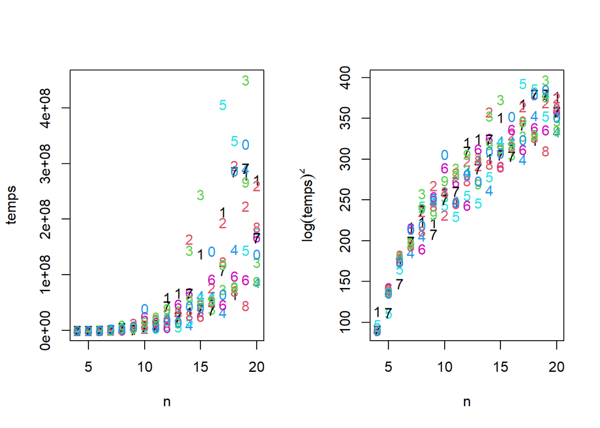

```r
set.seed(35)
par(mfrow=c(1,2)) # 2 graphiques sur 1 ligne
matplot(seqn, temps, xlab='n', ylab='temps')
matplot(seqn, log(temps)^2, xlab='n', ylab=expression(log(temps)^2))
```

L’observation des résultats nous permet de suspecter une relation linéaire, même si le deuxième graphe montre une relation qui semble légèrement logarithmique.

On crée le modèle de régression linéaire de $\log(temps)^2$ en fonction de $n$ :

```r
set.seed(35)
vect_temps <- log(as.vector(temps))^2
vect_dim <- rep(seqn, times=10)
temps.lm <- lm(vect_temps ~ vect_dim)
summary(temps.lm)
```

```
##
## Call:
## lm(formula = vect_temps ~ vect_dim)
##
## Residuals:
##     Min      1Q  Median      3Q     Max
## -63.730 -21.034   1.813  21.077  69.365
##
## Coefficients:
##             Estimate Std. Error t value Pr(>|t|)
## (Intercept)  83.4412     5.7596   14.49   <2e-16 ***
## vect_dim     15.3050     0.4444   34.44   <2e-16 ***
## ---
## Signif. codes:  0 '***' 0.001 '**' 0.01 '*' 0.05 '.' 0.1 ' ' 1
##
## Residual standard error: 28.38 on 168 degrees of freedom
## Multiple R-squared:  0.876,  Adjusted R-squared:  0.8752
## F-statistic:  1186 on 1 and 168 DF,  p-value: < 2.2e-16
```

### Test de pertinence

Ici, la p-valeur de l’hypothèse $a=0$ (ligne vect_dim) est extrêmement inférieure à 5%, ainsi, l’hypothèse $a=0$ est rejetée avec une grande confiance. Le modèle linéaire est pertinent.

### Etude des résidus

#### Test de normalité

Comme précédemment, le test de normalité est per le test de Shapiro, avec un seuil de risque de 5% :

```r
shapiro.test(residuals(temps.lm))
```

```
##
##  Shapiro-Wilk normality test
##
## data:  residuals(temps.lm)
## W = 0.98768, p-value = 0.1428
```

##### Etude graphique

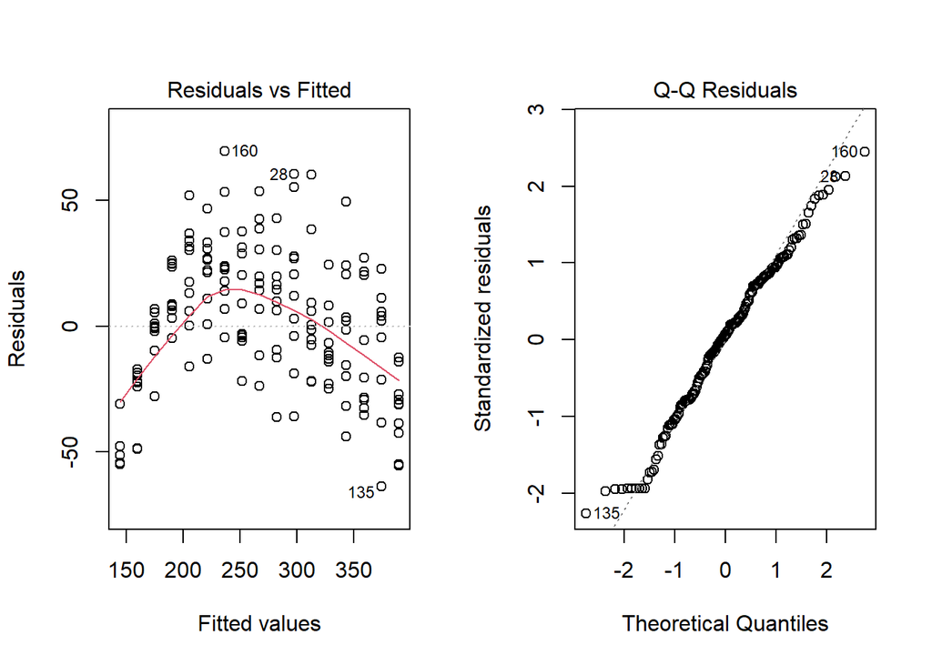

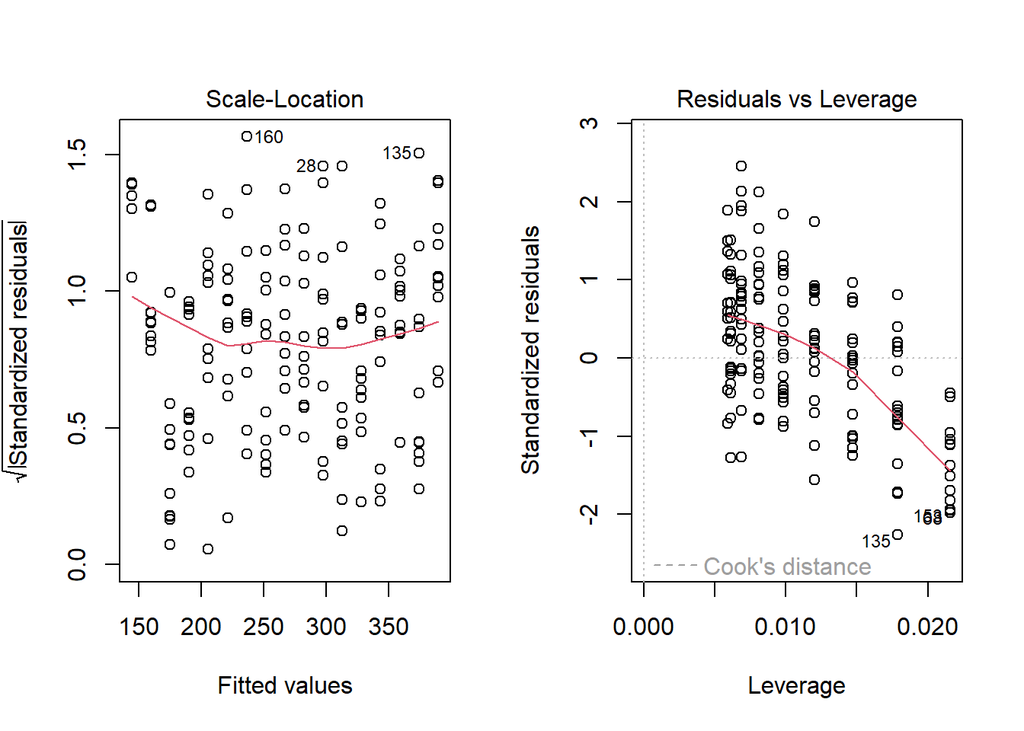

```r
par(mfrow=c(1,2)) # 4 graphiques sur 2 lignes et 2 colonnes
plot(temps.lm)
```

## 2.2. Comportement par rapport au nombre de sommets : étude du comportement moyen

Récupération du temps moyen.

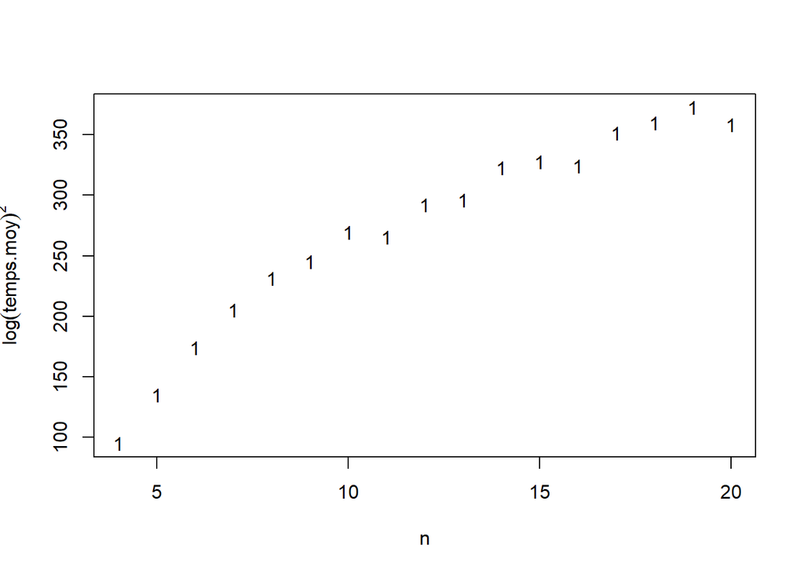

```r
temps.moy <- rowMeans(temps)
matplot(seqn, log(temps.moy)^2, xlab='n', ylab=expression(log(temps.moy)^2))
```

Analyse de la validité du modèle :

- pertinence des coefficients et du modèle,

```r
vect_moy <- log(as.vector(temps.moy))^2
vect_dim_moy <- rep(seqn)
temps.moy.lm <- lm(vect_dim_moy ~ vect_moy)
summary(temps.moy.lm)
```

```
##
## Call:
## lm(formula = vect_dim_moy ~ vect_moy)
##
## Residuals:
##     Min      1Q  Median      3Q     Max
## -1.8457 -1.0285 -0.2932  0.9209  2.8980
##
## Coefficients:
##              Estimate Std. Error t value Pr(>|t|)
## (Intercept) -4.129763   1.236126  -3.341  0.00447 **
## vect_moy     0.059258   0.004359  13.594 7.72e-10 ***
## ---
## Signif. codes:  0 '***' 0.001 '**' 0.01 '*' 0.05 '.' 0.1 ' ' 1
##
## Residual standard error: 1.429 on 15 degrees of freedom
## Multiple R-squared:  0.9249, Adjusted R-squared:  0.9199
## F-statistic: 184.8 on 1 and 15 DF,  p-value: 7.724e-10
```

- étude des hypothèses sur les résidus.

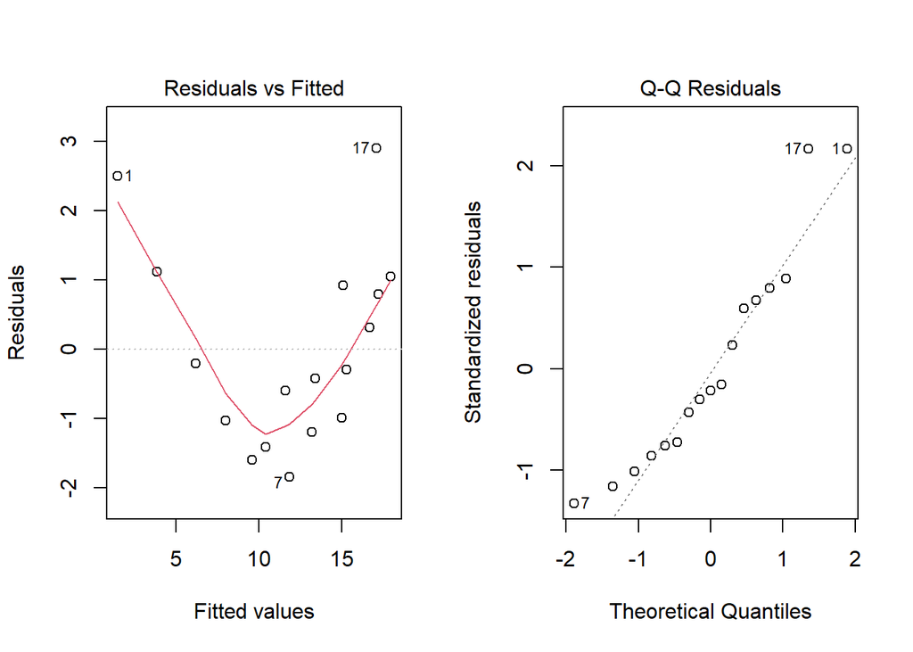

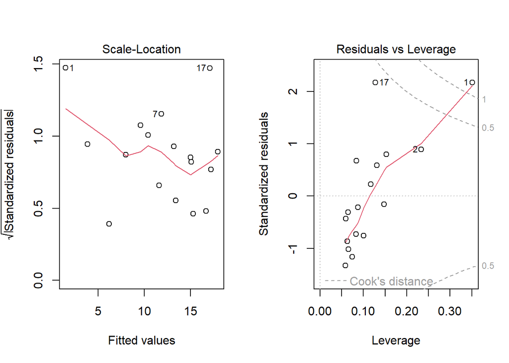

```r
par(mfrow=c(1,2)) # 4 graphiques sur 2 lignes et 2 colonnes
plot(temps.moy.lm)
```

```r
shapiro.test(residuals(temps.moy.lm))
```

```
##
##  Shapiro-Wilk normality test
##
## data:  residuals(temps.moy.lm)
## W = 0.93542, p-value = 0.2679
```

## 2.3. Comportement par rapport à la structure du graphe

Lecture du fichier ‘DonneesTSP.csv’.

```r
data.graph <- read.csv(file='DonneesTSP.csv',header=TRUE)
str(data.graph)
```

```
## 'data.frame':    70 obs. of  8 variables:
##  $ tps      : num  53692 144081 997803 2553322 6333009 ...
##  $ dim      : int  4 6 8 10 12 14 16 18 20 4 ...
##  $ mean.long: num  0.391 0.442 0.334 0.276 0.254 ...
##  $ mean.dist: num  0.665 0.592 0.537 0.506 0.502 ...
##  $ sd.dist  : num  0.276 0.259 0.246 0.238 0.227 ...
##  $ mean.deg : num  3 5 7 9 11 13 15 17 19 3 ...
##  $ sd.deg   : num  0 0 0 0 0 0 0 0 0 0 ...
##  $ diameter : num  1 1 1 1 1 1 1 1 1 1 ...
```

```r
data.graph$log.tps <- log(data.graph$tps)#log(donnees$tps)^2
data.graph$sqrt.dim <- sqrt(data.graph$dim)
data.graph$tps <- c() #on retire les variables tps et dim devenues inutiles
data.graph$dim <- c()
str(data.graph)
```

```
## 'data.frame':    70 obs. of  8 variables:
##  $ mean.long: num  0.391 0.442 0.334 0.276 0.254 ...
##  $ mean.dist: num  0.665 0.592 0.537 0.506 0.502 ...
##  $ sd.dist  : num  0.276 0.259 0.246 0.238 0.227 ...
##  $ mean.deg : num  3 5 7 9 11 13 15 17 19 3 ...
##  $ sd.deg   : num  0 0 0 0 0 0 0 0 0 0 ...
##  $ diameter : num  1 1 1 1 1 1 1 1 1 1 ...
##  $ log.tps  : num  10.9 11.9 13.8 14.8 15.7 ...
##  $ sqrt.dim : num  2 2.45 2.83 3.16 3.46 ...
```

```r
modele.complet = lm(data.graph$log.tps~., data = data.graph)
```

Mise en uvre d’une sélection de variables pour ne garder que les variables pertinentes.

Analyse de la validité du modèle :

```r
step(modele.complet)
```

```
## Start:  AIC=-165.23
## data.graph$log.tps ~ mean.long + mean.dist + sd.dist + mean.deg +
##     sd.deg + diameter + sqrt.dim
##
##             Df Sum of Sq     RSS      AIC
## - diameter   1    0.0145  5.2711 -167.038
## <none>                    5.2566 -165.230
## - sd.deg     1    0.2182  5.4748 -164.384
## - mean.dist  1    0.3014  5.5581 -163.327
## - mean.deg   1    0.8757  6.1324 -156.444
## - mean.long  1    3.6951  8.9517 -129.965
## - sd.dist    1    4.4335  9.6902 -124.417
## - sqrt.dim   1   17.3311 22.5877  -65.176
##
## Step:  AIC=-167.04
## data.graph$log.tps ~ mean.long + mean.dist + sd.dist + mean.deg +
##     sd.deg + sqrt.dim
##
##             Df Sum of Sq     RSS      AIC
## <none>                    5.2711 -167.038
## - sd.deg     1    0.2065  5.4776 -166.349
## - mean.dist  1    0.6554  5.9265 -160.835
## - mean.deg   1    0.9820  6.2531 -157.080
## - mean.long  1    3.8220  9.0931 -130.869
## - sd.dist    1    4.9133 10.1844 -122.935
## - sqrt.dim   1   18.7788 24.0499  -62.785
```

```
##
## Call:
## lm(formula = data.graph$log.tps ~ mean.long + mean.dist + sd.dist +
##     mean.deg + sd.deg + sqrt.dim, data = data.graph)
##
## Coefficients:
## (Intercept)    mean.long    mean.dist      sd.dist     mean.deg       sd.deg
##    6.396008    -4.854857    -0.002284     0.004883    -0.140823     0.126916
##    sqrt.dim
##    3.444077
```

- pertinence des coefficients et du modèle,
- étude des hypothèses sur les résidus.

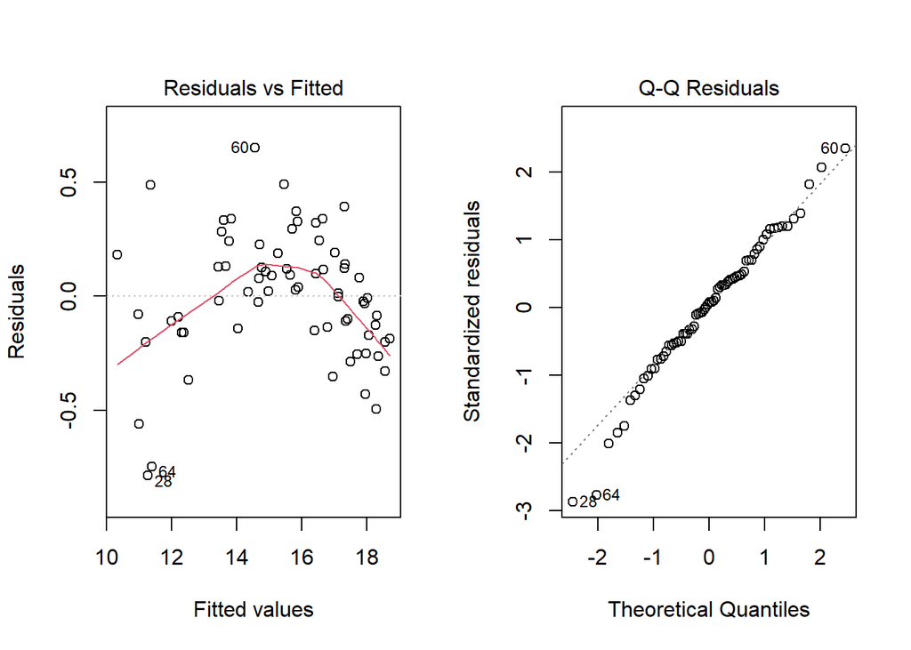

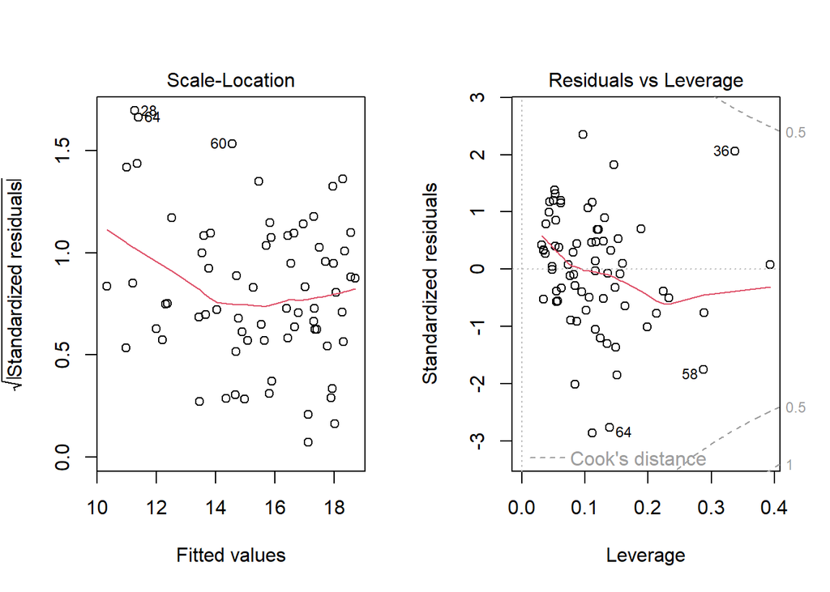

```r
par(mfrow=c(1,2)) # 4 graphiques sur 2 lignes et 2 colonnes
plot(modele.complet)
```

```r
shapiro.test(residuals(modele.complet))
```

```
##
##  Shapiro-Wilk normality test
##
## data:  residuals(modele.complet)
## W = 0.98289, p-value = 0.455
```